# Reproducible Research - Course Project 1

César Carrera

6/7/2020

## Introduction

This document containts the scritps require for the Course Project 1 of the Reproducible Research course, acording to the instructions.

## Reading and processing

Loading libraries

Reading the data:

```r
data <- read.csv("activity.csv")
str(data)
```

```
## 'data.frame':    17568 obs. of  3 variables:
##  $ steps   : int  NA NA NA NA NA NA NA NA NA NA ...
##  $ date    : Factor w/ 61 levels "2012-10-01","2012-10-02",..: 1 1 1 1 1 1 1 1 1 1 ...
##  $ interval: int  0 5 10 15 20 25 30 35 40 45 ...
```

Processing: We need to format the date variable and create the identifier for weekday and weekend.

```r
data <- data %>%
    mutate(date_format = ymd(data$date))
```

##Histogram of the total number of steps taken each day First, we calculate the total number of steps taken per day.

```r
data <- data %>%
    group_by(date_format) %>%
    mutate(steps_by_day = sum(steps, na.rm = TRUE)) %>%
    ungroup()

data$steps_by_day[is.na(data$steps)] <- NA_real_
```

The histogram for the steps taken per day is:

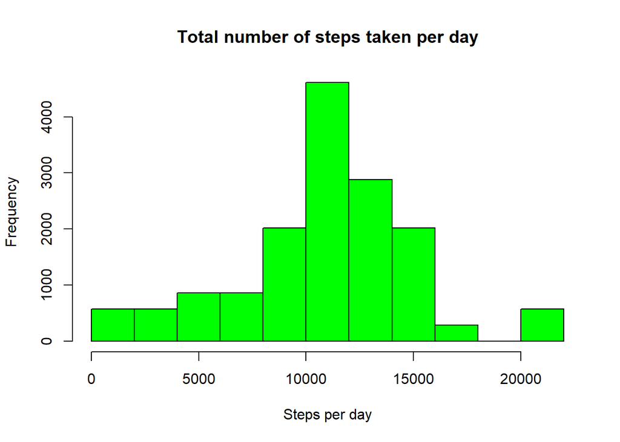

```r
hist(data$steps_by_day, main = "Total number of steps taken per day", xlab = "Steps per day", col="green")
```

##Average number of steps taken

```r
average_steps <- data %>%
    group_by(interval) %>%
    summarise(average_by_interval = mean(steps, na.rm = TRUE)) %>%
    ungroup()
```

The time series plot of the average number of steps taken is the following:

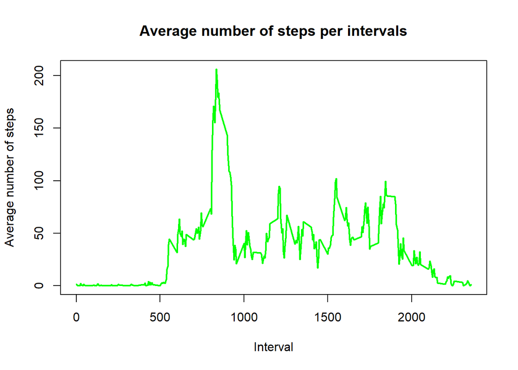

```r
plot(average_steps$interval, average_steps$average_by_interval, type = "l", lwd = 2, col="green", xlab="Interval", ylab="Average number of steps", main="Average number of steps per intervals")
```

The interval with the maximum number of steps is: **835**.

##Imputing missing values

Calculate and report the total number of missing values in the dataset (i.e. the total number of rows with NAs)

```r
summary(data)
```

```
##      steps                date          interval       date_format
##  Min.   :  0.00   2012-10-01:  288   Min.   :   0.0   Min.   :2012-10-01
##  1st Qu.:  0.00   2012-10-02:  288   1st Qu.: 588.8   1st Qu.:2012-10-16
##  Median :  0.00   2012-10-03:  288   Median :1177.5   Median :2012-10-31
##  Mean   : 37.38   2012-10-04:  288   Mean   :1177.5   Mean   :2012-10-31
##  3rd Qu.: 12.00   2012-10-05:  288   3rd Qu.:1766.2   3rd Qu.:2012-11-15
##  Max.   :806.00   2012-10-06:  288   Max.   :2355.0   Max.   :2012-11-30
##  NA's   :2304     (Other)   :15840
##   steps_by_day
##  Min.   :   41
##  1st Qu.: 8841
##  Median :10765
##  Mean   :10766
##  3rd Qu.:13294
##  Max.   :21194
##  NA's   :2304
```

There are 2304 cases of NA’s in the variable steps.

```r
data2 <- data %>%
    group_by(date_format) %>%
    mutate(steps_by_day = sum(steps, na.rm = TRUE)) %>%
    ungroup()

data2 <- data2 %>%
    mutate(steps_no_na = case_when(!is.na(steps) ~ steps, TRUE ~ steps_by_day))

summary(data2)
```

```
##      steps                date          interval       date_format
##  Min.   :  0.00   2012-10-01:  288   Min.   :   0.0   Min.   :2012-10-01
##  1st Qu.:  0.00   2012-10-02:  288   1st Qu.: 588.8   1st Qu.:2012-10-16
##  Median :  0.00   2012-10-03:  288   Median :1177.5   Median :2012-10-31
##  Mean   : 37.38   2012-10-04:  288   Mean   :1177.5   Mean   :2012-10-31
##  3rd Qu.: 12.00   2012-10-05:  288   3rd Qu.:1766.2   3rd Qu.:2012-11-15
##  Max.   :806.00   2012-10-06:  288   Max.   :2355.0   Max.   :2012-11-30
##  NA's   :2304     (Other)   :15840
##   steps_by_day    steps_no_na
##  Min.   :    0   Min.   :  0.00
##  1st Qu.: 6778   1st Qu.:  0.00
##  Median :10395   Median :  0.00
##  Mean   : 9354   Mean   : 32.48
##  3rd Qu.:12811   3rd Qu.:  0.00
##  Max.   :21194   Max.   :806.00
##
```

As shown, the variable steps_no_na has no NA’s. Now we plot the histogram for the new variable:

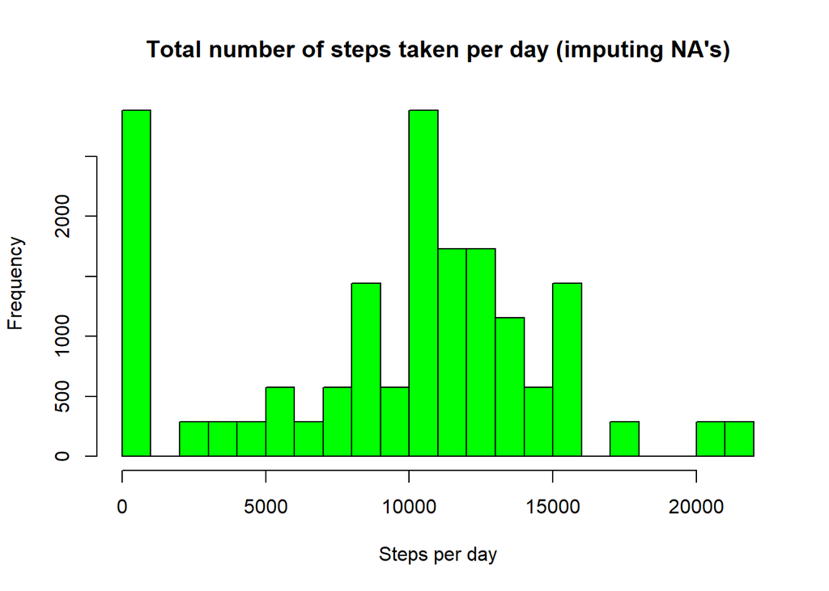

```r
data2 <- data2 %>%
    group_by(date_format) %>%
    mutate(steps_by_day_no_na = sum(steps_no_na, na.rm = TRUE)) %>%
    ungroup()

hist(data2$steps_by_day_no_na, main = "Total number of steps taken per day (imputing NA's)", xlab = "Steps per day", col="green")
```

The mean of the total number of steps taken per day (with no NA’s) is **9354.23** and the median of the total number of steps taken per day is **10395**.

##Differences in activity patterns between weekdays and weekends

First, we create the factor variable for weekday and weekend:

```r
data2 <- data2 %>%
    mutate(day_name = weekdays(date_format),
           day_type = case_when(day_name=="sábado" | day_name=="domingo" ~ "Weekend", TRUE ~ "Weekday"))
```

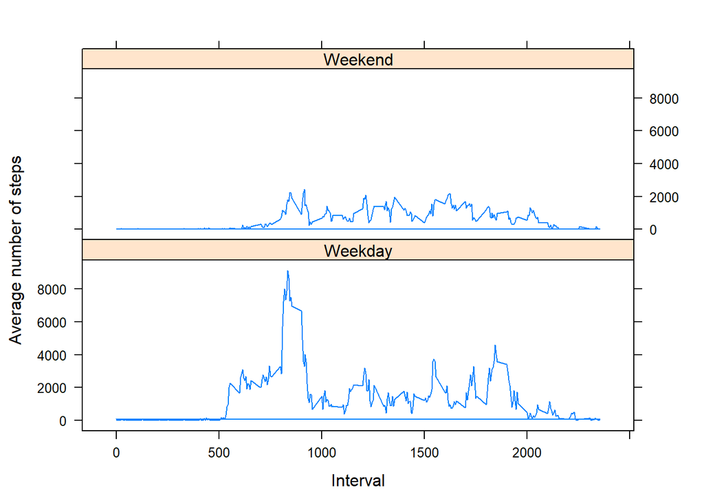

```r
data2 <- data2 %>%
    group_by(interval, day_type) %>%
    mutate(steps_by_day_type = sum(steps_no_na, na.rm = TRUE)) %>%
    ungroup()

xyplot(steps_by_day_type ~ interval | day_type, data2, type = "l", layout = c(1, 2),
    xlab = "Interval", ylab = "Average number of steps")
```